## Reproducible Research

```r
##Set the current working directory which contains the dataset
#setwd("~/repdata_data_activity")
```

#### Load the required Libraries

```r
library(ggplot2)
library(dplyr)
library(tidyr)
library(lattice)
```

### Code for reading in the dataset and/or processing the data

Load the data using read.csv function

```r
dataSet<- read.csv("activity.csv")
```

Process/transform the data (if necessary) into a format suitable for your analysis

```r
date<-as.Date(dataSet$date)
## Converting the date column to required format (Date-Month-Year)
dataSet$date<-format(date,"%d-%A-%Y")
```

Omitting the NA values and saving the data to “new” variable

```r
new<-na.omit(dataSet) ## new data set
```

### Histogram of the total number of steps taken each day

Calculate the total number of steps taken per day

```r
daywise<-tapply(new$steps,new$date,sum)
```

Histogram displays steps taken per day

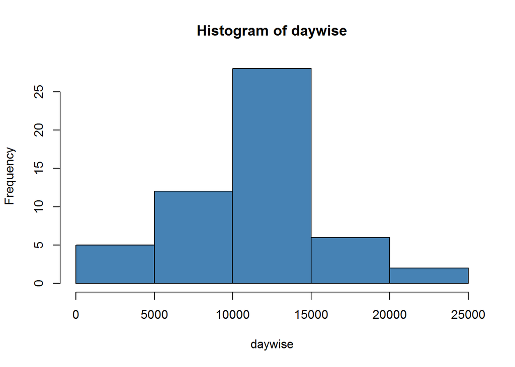

```r
hist(daywise,col = "steelblue")
```

### Mean and median number of steps taken each day

```r
summary(daywise)
```

```
##    Min. 1st Qu.  Median    Mean 3rd Qu.    Max.
##      41    8841   10765   10766   13294   21194
```

[figure not shown]

```r
Timeseries<-aggregate(steps~interval,data=new,sum)
ggplot(Timeseries,aes(x=interval,y=steps))+geom_line()+ggtitle("Time series plot of the average number of steps taken")
```

```r
new$interval[which.max(new$steps)]
```

```
## [1] 615
```

### Code to describe and show a strategy for imputing missing data

```r
## Saving the original data to new variable
dataSet_new <- dataSet
```

```r
count<-is.na(dataSet_new$steps) %>% sum()
```

Devise a strategy for filling in all of the missing values in the dataset. The strategy does not need to be sophisticated. For example, you could use the mean/median for that day, or the mean for that 5-minute interval, etc.

```r
dataSet_new[is.na(dataSet_new)]<- mean(dataSet$steps,na.rm = TRUE)
```

Create a new dataset that is equal to the original dataset but with the missing data filled in.

```r
print(paste("No. of rows in original data set :",nrow(dataSet)))
```

```
## [1] "No. of rows in original data set : 17568"
```

```r
print(paste("No. of rows in new data set :",nrow(dataSet_new)))
```

```
## [1] "No. of rows in new data set : 17568"
```

```r
print(head(dataSet_new,10))
```

```
##      steps           date interval
## 1  37.3826 01-Monday-2012        0
## 2  37.3826 01-Monday-2012        5
## 3  37.3826 01-Monday-2012       10
## 4  37.3826 01-Monday-2012       15
## 5  37.3826 01-Monday-2012       20
## 6  37.3826 01-Monday-2012       25
## 7  37.3826 01-Monday-2012       30
## 8  37.3826 01-Monday-2012       35
## 9  37.3826 01-Monday-2012       40
## 10 37.3826 01-Monday-2012       45
```

### Histogram of the total number of steps taken each day after missing values are imputed

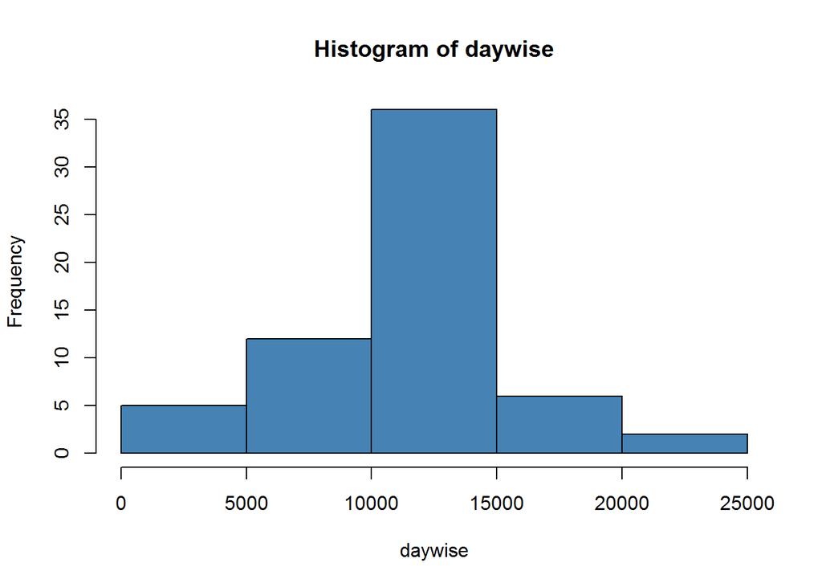

```r
daywise<-tapply(dataSet_new$steps,dataSet_new$date,sum)
hist(daywise,col = "steelblue")
```

### Panel plot comparing the average number of steps taken per 5-minute interval across weekdays and weekends

Create a new factor variable in the dataset with two levels – “weekday” and “weekend” indicating whether a given date is a weekday or weekend day.

```r
dataSet_new$day<-format(as.Date(date,"%d-%A-%Y"),format="%A")
dataSet_new$Week<- ifelse(dataSet_new$day %in% c("Sunday","Saturday") ,"Weekends","Weekdays")
```

Make a panel plot containing a time series plot of the 5-minute interval (x-axis) and the average number of steps taken, averaged across all weekday days or weekend days (y-axis)

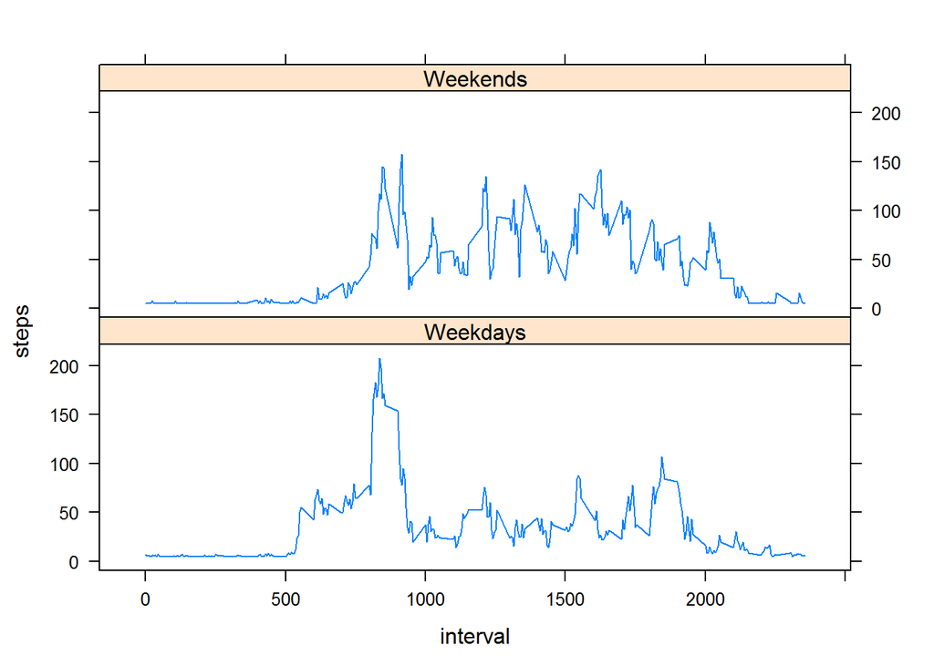

```r
stepsByDay<-aggregate(steps~Week+interval,data = dataSet_new,mean)
xyplot(steps~interval|Week,data= stepsByDay,layout=c(1,2),type="l")
```